# code_paper

### Sample code for classifying Positive and Unlabelled observations

#### Naive Bayes with multidimensional Kernel Density Estimation (KDE) and dimensionality reduction using a Principal Component Analysis (PCA)

The classifying algorithm, written in python using the scikit-learn library, consists of three steps. (i) First, the input data is transformed and standardized so that the mean is zero and the variance equals one. Then, a principal component analysis is performed to reduce the dimensionality of the data.

```python
# open packages
import numpy as np
import pandas as pd
from sklearn import preprocessing
from sklearn.decomposition import PCA
from sklearn.model_selection import GridSearchCV
from sklearn.neighbors import KernelDensity
import matplotlib.pyplot as plt
import matplotlib.colors as mcolors
```

```python
# open labelled (lab), unlabelled (unlab) and negative (neg) data (in this example randomly
# sampled data is used)
lab_raw   = pd.DataFrame(np.random.randn(100, 6)+10,
                        columns=['feature_1','feature_2','feature_3',
                                 'feature_4','feature_5','feature_6'])
unlab_raw = pd.DataFrame(np.random.randn(1000, 6)+11,
                        columns=['feature_1','feature_2','feature_3',
                                 'feature_4','feature_5','feature_6'])
neg_raw   = pd.DataFrame(np.random.randn(80, 6)+11.2,
                        columns=['feature_1','feature_2','feature_3',
                                 'feature_4','feature_5','feature_6'])


# transform data (if needed)
# lab_raw['feature_3']   = np.log10(labelled_raw['feature_3'])
# unlab_raw['feature_3'] = np.log10(unlabelled_raw['feature_3'])
# neg_raw['feature_3']   = np.log10(neg_raw['feature_3'])

# standardize data
scaler = preprocessing.StandardScaler().fit(pd.concat([lab_raw,unlab_raw]).values)
lab_st   = scaler.transform(lab_raw)
unlab_st = scaler.transform(unlab_raw)
neg_st   = scaler.transform(neg_raw)


# perform principal component analysis
pca = PCA().fit(np.concatenate([lab_st,unlab_st]))
lab_pcs   = pca.transform(lab_st)
unlab_pcs = pca.transform(unlab_st)
neg_pcs   = pca.transform(neg_st)


# split up in train, calibration and test (in this example arbitrary)
lab_train   = lab_pcs[:50]
pos_cal     = lab_pcs[50:80]
pos_test    = lab_pcs[80::]
unlab_train = unlab_pcs
neg_cal     = neg_pcs[0:40]
neg_test    = neg_pcs[40::]

# select the number of principal components (defined by the amount of training data (see
# "Silverman, B.W.. Denity Estimation for Statistics and Data Analysis. (Chapman an Hall,
# 1986)")
pcmax = 2 # number of principal components
```

(ii) The multidimensional densities of the first x principal components of the labelled and unlabelled observations are estimated through a KDE with a ten-fold cross-validation to obtain the bandwidth parameter. To reduce computation time, a random subset of the observations can be used.

```python
# perform kernel density estimation for labelled data
# reorganize data
lab_train_forkde  = np.array(lab_train[:,0:pcmax].tolist()).squeeze()

# define possible bandwiths
bandwidths_lab = np.linspace(0.5,1,30)

# perform gridsearch (cross-validation) to estimate optimal bandwith
grid_lab = GridSearchCV(KernelDensity(kernel='gaussian'),
                    {'bandwidth': bandwidths_lab},
                    cv = 10)
grid_lab.fit(lab_train_forkde);

# check whether bandwith is between the limits of the bandwiths
if (grid_lab.best_params_['bandwidth']==bandwidths_lab[0]) or \
   (grid_lab.best_params_['bandwidth']==bandwidths_lab[-1]):
    print('adjust bandwiths!', grid_lab.best_params_)
else:
    print(grid_lab.best_params_['bandwidth'])
    bw_lab = grid_lab.best_params_['bandwidth']

# estimate density using the selected bandwidth
kde_lab = KernelDensity(bandwidth=bw_lab).fit(lab_train_forkde)
```

```
0.5344827586206896
```

```python
# perform kernel density estimation for unlabelled data
# select a random subset
unlab_train_subset = pd.DataFrame(unlab_train).sample(100).values
# reorganize data
unlab_train_forkde  = np.array(unlab_train_subset[:,0:pcmax].tolist()).squeeze()

# define possible bandwiths
bandwidths_unlab = np.linspace(0.4,0.6,30)

# perform gridsearch (cross-validation) to estimate optimal bandwith
grid_unlab = GridSearchCV(KernelDensity(kernel='gaussian'),
                    {'bandwidth': bandwidths_unlab},
                    cv = 10)
grid_unlab.fit(unlab_train_forkde);

# check whether bandwith is between the limits of the bandwiths
if (grid_unlab.best_params_['bandwidth']==bandwidths_unlab[0]) or \
   (grid_unlab.best_params_['bandwidth']==bandwidths_unlab[-1]):
    print('adjust bandwiths!', grid_unlab.best_params_)
else:
    print(grid_unlab.best_params_['bandwidth'])
    bw_unlab = grid_unlab.best_params_['bandwidth']

# estimate density using the findal bandwidth
kde_unlab = KernelDensity(bandwidth=bw_unlab).fit(unlab_train_forkde)
```

```
0.5241379310344827
```

(iii) The decision rule is applied to classify observations as positive or negative.  
$p\left(y=1\right)=\ \frac{n_{labelled}\times\lambda}{n_{labelled}\times\lambda+\ n_{unlabelled}}$ and $ p\left(y=0\right)=\ \frac{n_{unlabelled}}{n_{labelled}\times\lambda+\ n_{unlabelled}}$ (Eq. 1)

$\mathrm{p}\left(\mathrm{y=1}\middle|\mathrm{x}\right)\mathrm{\approx\ }\frac{\mathrm{p(x|s=1)\times\ p} \left(\mathrm{y=1}\right)}{\mathrm{p}\left(\mathrm{x}\middle|\mathrm{s=1}\right)\mathrm{\times p} \left(\mathrm{y=1}\right)\mathrm{+p} \left(\mathrm{x} \middle|\mathrm{s=0}\right)\mathrm{\times p(y=0)} }$ (Eq. 2a)

$\mathrm{p}\left(\mathrm{y}=0\middle|\mathbf{x}\right)\approx\ \frac{\mathrm{p}\left(\mathbf{x}\middle|\mathrm{s}=0\right)\times \mathrm{p}\left(\mathrm{y}=0\right)}{\mathrm{p}\left(\mathbf{x}\middle|\mathrm{s}=1\right)\times \mathrm{p}\left(\mathrm{y}=1\right)+\mathrm{p}\left(\mathbf{x}\middle|\mathrm{s}=0\right)\times \mathrm{p}\left(\mathrm{y}=0\right)}$ (Eq. 2b)

```python
# apply the estimated densities to all calibration data (score calibration data)
pos_cal_toscore  = np.array(pos_cal[:,0:pcmax].tolist()).squeeze()
neg_cal_toscore  = np.array(neg_cal[:,0:pcmax].tolist()).squeeze()
scores_pos_cal_lab   = np.exp(kde_lab.score_samples(pos_cal_toscore))
scores_neg_cal_lab   = np.exp(kde_lab.score_samples(neg_cal_toscore))
scores_pos_cal_unlab = np.exp(kde_unlab.score_samples(pos_cal_toscore))
scores_neg_cal_unlab = np.exp(kde_unlab.score_samples(neg_cal_toscore))
```

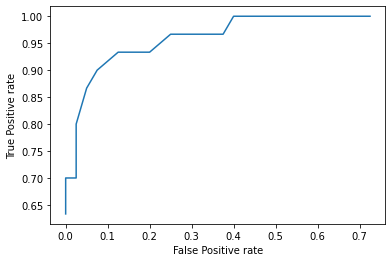

```python
# calculate ROC curve (consisting of TPrate and FPrate) to empirically select the value for
# the cost parameter labda

# define possible values of the cost parameter labda (Eq. 1)
labdas = np.linspace(1,1000,100)

# define empty arrays for the true positive (TPrate) and false positive rates (FPrate)
TPrate = np.zeros(len(labdas))
FPrate = np.zeros(len(labdas))

# define a function to calculate p(y=1|x) and p(y=0|x)
def probs(input_scores_lab,input_scores_unlab,py1,py0):
    py1gx = (input_scores_lab*py1)/(input_scores_lab*py1 + input_scores_unlab*py0)
    py0gx = (input_scores_unlab*py0)/(input_scores_lab*py1 + input_scores_unlab*py0)
    return py1gx, py0gx

# loop over all values of the cost parameter labda
for labda in range(len(labdas)):
    # calculate p(y=1) and p(y=0)
    py1 = len(lab_train)*labdas[labda]/(len(lab_train)*labdas[labda] +
                                   len(unlab_train))
    py0 = len(unlab_train)/(len(lab_train)*labdas[labda] +
                                   len(unlab_train))
    # calculate p(y=1|x) and p(y=0|x) for positive and negative calibration data
    py1gx_pos_cal, py0gx_pos_cal = probs(scores_pos_cal_lab,scores_pos_cal_unlab,py1,py0)
    py1gx_neg_cal, py0gx_neg_cal = probs(scores_neg_cal_lab,scores_neg_cal_unlab,py1,py0)
    # calculate the true positive (TPrate) and false positive rates (FPrate)
    TPrate[labda] = len(py1gx_pos_cal[(py1gx_pos_cal)>0.5])/len(py1gx_pos_cal)
    FPrate[labda] = len(py1gx_neg_cal[(py1gx_neg_cal)>0.5])/len(py1gx_neg_cal)

# plot ROC curve
plt.plot(FPrate,TPrate)
plt.xlabel('False Positive rate')
plt.ylabel('True Positive rate');
```

```python
# select value of the cost parameter (corresponding to an operating point on the ROC curve),
# using the harmonic mean of the precision and sensitivity estimated by the calibration data

# transform true positive and false positive rates to number of true positives, true
# negatives, false positives, and false negatives
TP = TPrate*len(pos_cal)
TN = (1-FPrate)*len(neg_cal)
FP = FPrate*len(neg_cal)
FN = (1-TPrate)*len(pos_cal)

# calculate the precision and the sensitivity and the harmonic mean between these two (F1)
precision = TP/(TP+FP)
sensitivity = TP/(TP+FN)
F1 = 2*precision*sensitivity/(precision+sensitivity)
# plt.plot(labdas,F1) # visualize

# select value of the cost parameter labda corresponding to the first maximum value of F1
labda_selected = labdas[F1==F1.max()][0]
#plt.scatter(labda_selected,F1.max()) # visualize
# print corresponding precision and sensitivity
# print('precision: ', *precision[F1==F1.max()]*100, '% \n' \
#      'sensitivity: ', *sensitivity[F1==F1.max()]*100, '%')
```

```python
# classify test data and compute confusion matrix

# score test data
pos_test_toscore  = np.array(pos_test[:,0:pcmax].tolist()).squeeze()
neg_test_toscore  = np.array(neg_test[:,0:pcmax].tolist()).squeeze()
scores_pos_test_lab   = np.exp(kde_lab.score_samples(pos_test_toscore))
scores_neg_test_lab   = np.exp(kde_lab.score_samples(neg_test_toscore))
scores_pos_test_unlab = np.exp(kde_unlab.score_samples(pos_test_toscore))
scores_neg_test_unlab = np.exp(kde_unlab.score_samples(neg_test_toscore))

# calculate p(y=1) and p(y=0) with the selected value for labda (Eq. 1)
py1 = len(lab_train)*labda_selected/(len(lab_train)*labda_selected + len(unlab_train))
py0 = len(unlab_train)/(len(lab_train)*labda_selected + len(unlab_train))

# calculate p(y=1|x) and p(y=0|x) for positive and negative calibration data (Eq. 2)
py1gx_pos_test, py0gx_pos_test = probs(scores_pos_test_lab,scores_pos_test_unlab,py1,py0)
py1gx_neg_test, py0gx_neg_test = probs(scores_neg_test_lab,scores_neg_test_unlab,py1,py0)

# calculate the number of true positives, true
# negatives, false positives, and false negatives
TP_test = len(py1gx_pos_test[(py1gx_pos_test)>0.5])
TN_test = len(py1gx_neg_test[(py1gx_neg_test)<0.5])
FP_test = len(py1gx_neg_test[(py1gx_neg_test)>0.5])
FN_test = len(py1gx_pos_test[(py1gx_pos_test)<0.5])

# construct confusion matrix
CM = pd.DataFrame(((TP_test,FP_test),(FN_test,TN_test)),
             ['predicted positive','predicted negative'],
             ['observed positive','observed negative'])
print(CM)
```

```
                    observed positive  observed negative
predicted positive                 19                  4
predicted negative                  1                 36
```

Visualize the classification (conceptual)

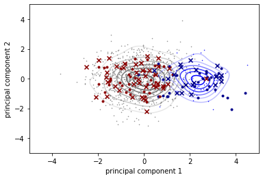

```python
# plot 2d graph of the sample training data, the estimated density and the test data

# plot labelled and unlabelled training data
plt.scatter(unlab_train[:,0],unlab_train[:,1],marker='.',s=1,
            label='unlabelled training data',zorder=1,color='gray')
plt.scatter(lab_train[:,0],lab_train[:,1],marker='.',s=1,
            label='labelled training data',zorder=1,color='blue')

# plot estimated density distributions
# define colormaps
colors = [(0.2,0.2,0.2,c) for c in np.linspace(0,1,100)]
cmapred = mcolors.LinearSegmentedColormap.from_list('mycmap', colors, N=60)
colors = [(0,0,1,c) for c in np.linspace(0,1,100)]
cmapblue = mcolors.LinearSegmentedColormap.from_list('mycmap', colors, N=5)
# calculate density at gripoints
xx, yy = np.mgrid[-5:5:100j, -5:5:100j]
z_unlab = np.exp(kde_unlab.score_samples(np.vstack([yy.ravel(), xx.ravel()]).T))
z_lab = np.exp(kde_lab.score_samples(np.vstack([yy.ravel(), xx.ravel()]).T))
# plot density estimations at gridpoints
plt.contour(yy, xx, np.reshape(z_unlab, xx.shape),zorder=0,
              cmap=cmapred)
plt.contour(yy, xx, np.reshape(z_lab, xx.shape),zorder=0,
              cmap=cmapblue)

# plot calibration data
plt.scatter(pos_cal[:,0],pos_cal[:,1],marker='.',
            label='positive calibration data',zorder=1,color='darkblue')
plt.scatter(neg_cal[:,0],neg_cal[:,1],marker='.',
            label='negative calibration data',zorder=1,color='darkred')

# plot test data
plt.scatter(pos_test[:,0],pos_test[:,1],marker='x',
            label='positive test data',zorder=1,color='darkblue')
plt.scatter(neg_test[:,0],neg_test[:,1],marker='x',
            label='negative test data',zorder=1,color='darkred')

# plot labels/legend
plt.xlabel('principal component 1')
plt.ylabel('principal component 2');
#plt.legend()
```